# Introduction to {wpa}

Martin Chan

2021-09-01

## Background

This document walks through the **wpa** package, and provides some examples on how to use some of the functions. For our full online documentation for the package, please visit https://microsoft.github.io/wpa/. For anything else related to Workplace Analytics, please visit https://docs.microsoft.com/en-us/workplace-analytics/.

### Setting up

To start off using **wpa**, you’ll have to load it by running `library(wpa)`. For the purpose of our examples, let’s also load **dplyr** as a component package of **tidyverse** (alternatively, you can just run `library(tidyverse)`:

```r
library(wpa)
library(dplyr)
```

The package ships with a standard Person query dataset `sq_data`:

```r
data("sq_data") # Standard Query data

# Check what the first ten columns look like
sq_data %>%
  .[,1:10] %>%
  glimpse()
```

```
#> Rows: 13,442
#> Columns: 10
#> $ PersonId                                       <chr> "93F763956FFC939A5DDE7D~
#> $ Date                                           <chr> "11/3/2019", "11/10/201~
#> $ Workweek_span                                  <dbl> 42.50652, 39.78644, 42.~
#> $ Meetings_with_skip_level                       <dbl> 0, 0, 0, 0, 0, 0, 0, 1,~
#> $ Meeting_hours_with_skip_level                  <dbl> 0.00, 0.00, 0.00, 0.00,~
#> $ Generated_workload_email_hours                 <dbl> 12.283767, 11.890209, 9~
#> $ Generated_workload_email_recipients            <dbl> 179, 171, 131, 108, 78,~
#> $ Generated_workload_instant_messages_hours      <dbl> 1.0815250, 1.1650000, 0~
#> $ Generated_workload_instant_messages_recipients <dbl> 96, 94, 60, 61, 39, 64,~
#> $ Generated_workload_call_hours                  <dbl> 0.5000000, 0.0000000, 5~
```

## Example Analysis

### Collaboration Summary

The `collaboration_summary()` function allows you to generate a stacked bar plot summarising the email and meeting hours by an HR attribute you specify:

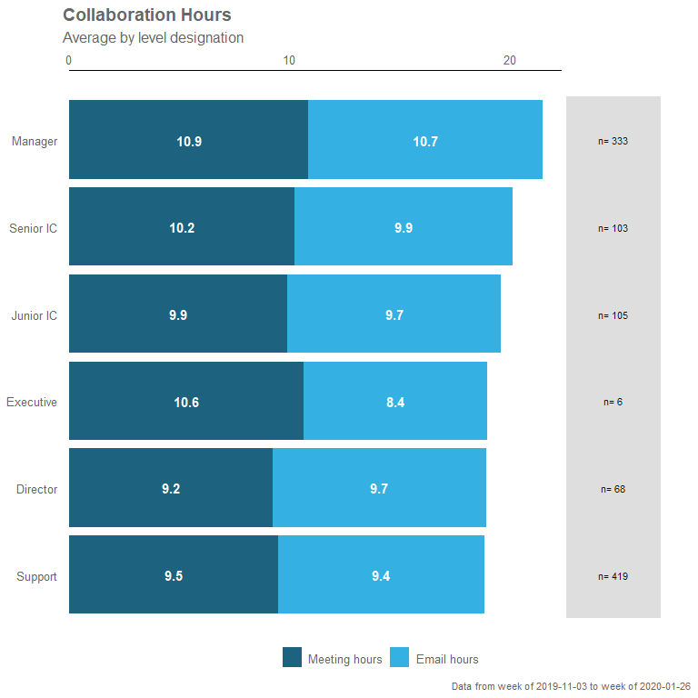

```r
sq_data %>% collaboration_summary(hrvar = "LevelDesignation")
```

By changing the `hrvar()` argument, you can change the data being shown easily:

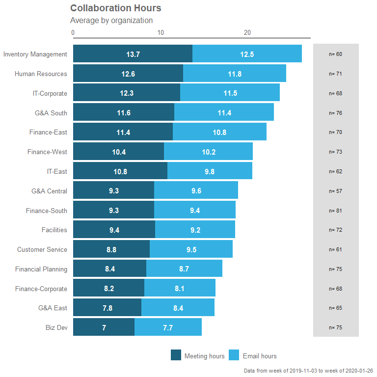

```r
sq_data %>% collaboration_summary(hrvar = "Organization")
```

The `collaboration_summary()` function also comes with an option to return summary tables, rather than plots. Just specify “table” in the `return` argument:

```r
sq_data %>% collaboration_summary(hrvar = "LevelDesignation", return = "table")
```

```
#> # A tibble: 6 x 5
#>   group     Meeting_hours Email_hours Total Employee_Count
#>   <chr>             <dbl>       <dbl> <dbl>          <int>
#> 1 Director           9.22        9.70  18.9             68
#> 2 Executive         10.6         8.36  19.0              6
#> 3 Junior IC          9.89        9.73  19.6            105
#> 4 Manager           10.9        10.7   21.5            333
#> 5 Senior IC         10.2         9.94  20.1            103
#> 6 Support            9.47        9.37  18.8            419
```

### Summary of Key Metrics

The `keymetrics_scan()` function allows you to produce summary metrics from the Standard Person Query data. Similar to most of the functions in this package, you can specify what output to return with the `return` argument. In addition, you have to specify which HR attribute/variable to use as a grouping variable with the `hrvar` argument.

There are two valid return values for `keymetrics_scan()`:

- Heat map (`return = "plot"`)
- Summary table (`return = "table"`)

And here are what the outputs look like.

Heatmap:

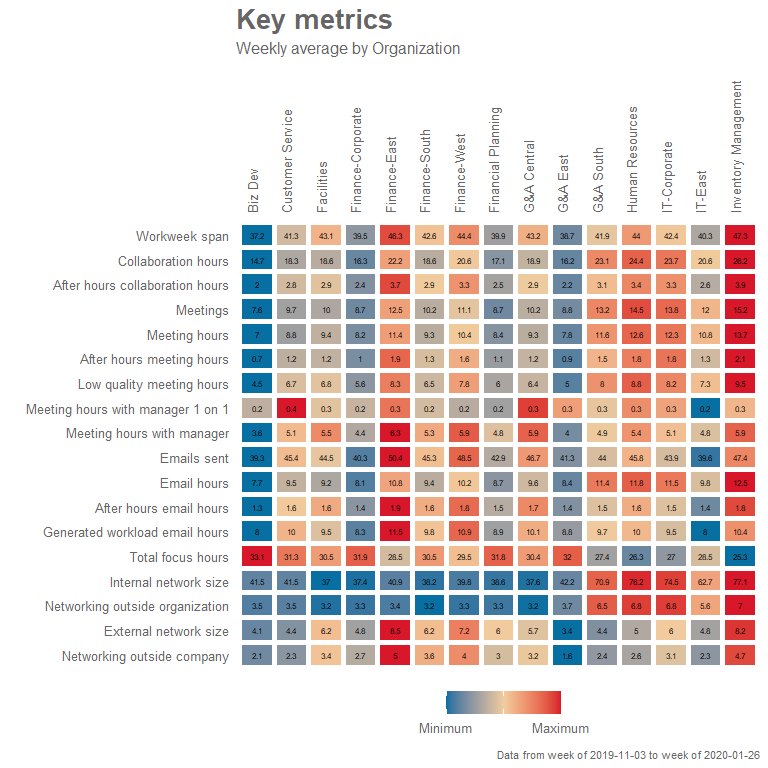

```r
sq_data %>% keymetrics_scan(hrvar = "Organization", return = "plot")
```

Summary table:

```r
sq_data %>% keymetrics_scan(hrvar = "Organization", return = "table")
```

```
#> # A tibble: 19 x 16
#>    variable             `Biz Dev` `Customer Servic~ Facilities `Finance-Corpora~
#>    <fct>                    <dbl>             <dbl>      <dbl>             <dbl>
#>  1 Workweek_span           37.2              41.3       43.1              39.5
#>  2 Collaboration_hours     14.7              18.3       18.6              16.3
#>  3 After_hours_collabo~     2.00              2.78       2.85              2.36
#>  4 Meetings                 7.63              9.72       9.96              8.73
#>  5 Meeting_hours            7.02              8.78       9.39              8.16
#>  6 After_hours_meeting~     0.722             1.20       1.21              0.959
#>  7 Low_quality_meeting~     4.52              6.67       6.79              5.60
#>  8 Meeting_hours_with_~     0.237             0.354      0.255             0.241
#>  9 Meeting_hours_with_~     3.60              5.10       5.53              4.44
#> 10 Emails_sent             39.3              45.4       44.5              40.3
#> 11 Email_hours              7.72              9.49       9.20              8.13
#> 12 After_hours_email_h~     1.27              1.58       1.64              1.40
#> 13 Generated_workload_~     7.98             10.0        9.53              8.34
#> 14 Total_focus_hours       33.1              31.3       30.5              31.9
#> 15 Internal_network_si~    41.5              41.5       37.0              37.4
#> 16 Networking_outside_~     3.47              3.53       3.21              3.31
#> 17 External_network_si~     4.07              4.40       6.19              4.80
#> 18 Networking_outside_~     2.09              2.29       3.38              2.69
#> 19 Employee_Count          75                61         72                68
#> # ... with 11 more variables: Finance-East <dbl>, Finance-South <dbl>,
#> #   Finance-West <dbl>, Financial Planning <dbl>, G&A Central <dbl>,
#> #   G&A East <dbl>, G&A South <dbl>, Human Resources <dbl>, IT-Corporate <dbl>,
#> #   IT-East <dbl>, Inventory Management <dbl>
```

## Meeting Habits

The `meeting_summary()` provides a very similar output to the previous functions, but focusses on meeting habit data. Again, the input data is the Standard Query, and you will need to specify a HR attribute/variable to use as a grouping variable with the `hrvar` argument.

> The idea is that functions in this package will share a consistent design, and the required arguments and outputs will be what users ‘expect’ as they explore the package. The benefit of this is to improve ease of use and adoption.

And here are what the outputs look like, for `meeting_summary()`.

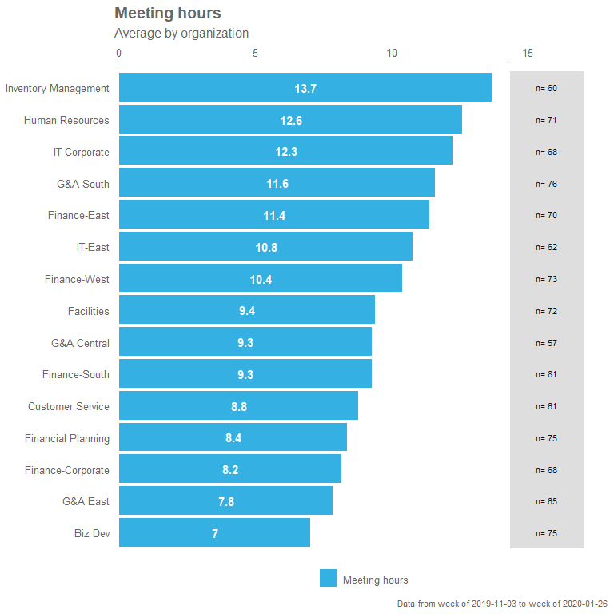

```r
sq_data %>% meeting_summary(hrvar = "Organization", return = "plot")
```

Summary table:

```r
sq_data %>% meeting_summary(hrvar = "Organization", return = "table")
```

```
#> # A tibble: 15 x 3
#>    group                Meeting_hours     n
#>    <chr>                        <dbl> <int>
#>  1 Biz Dev                       7.02    75
#>  2 Customer Service              8.78    61
#>  3 Facilities                    9.39    72
#>  4 Finance-Corporate             8.16    68
#>  5 Finance-East                 11.4     70
#>  6 Finance-South                 9.27    81
#>  7 Finance-West                 10.4     73
#>  8 Financial Planning            8.36    75
#>  9 G&A Central                   9.28    57
#> 10 G&A East                      7.84    65
#> 11 G&A South                    11.6     76
#> 12 Human Resources              12.6     71
#> 13 IT-Corporate                 12.3     68
#> 14 IT-East                      10.8     62
#> 15 Inventory Management         13.7     60
```

### Manager Relationship 2x2 Matrix

The `mgrrel_matrix()` function from {wpa} enables you to plot a 2 by 2 matrix straight from the Standard Query data, which is returned as a ggplot object:

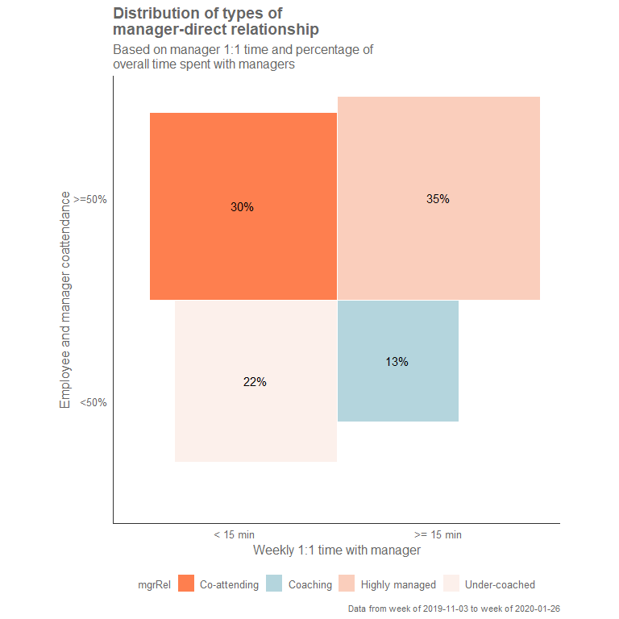

```r
sq_data %>% mgrrel_matrix()
```

By changing the `return` argument, you can also return a **summary table**:

```r
sq_data %>% mgrrel_matrix(hrvar = "LevelDesignation", return = "table")
```

```
#> # A tibble: 20 x 4
#>    mgrRel         LevelDesignation     n   perc
#>    <fct>          <chr>            <int>  <dbl>
#>  1 Co-attending   Junior IC           40 0.381
#>  2 Co-attending   Manager             78 0.234
#>  3 Co-attending   Senior IC           32 0.311
#>  4 Co-attending   Support            159 0.379
#>  5 Coaching       Director            23 0.338
#>  6 Coaching       Executive            2 0.333
#>  7 Coaching       Junior IC            4 0.0381
#>  8 Coaching       Manager             67 0.201
#>  9 Coaching       Senior IC           10 0.0971
#> 10 Coaching       Support             24 0.0573
#> 11 Highly managed Junior IC           51 0.486
#> 12 Highly managed Manager             82 0.246
#> 13 Highly managed Senior IC           47 0.456
#> 14 Highly managed Support            184 0.439
#> 15 Under-coached  Director            45 0.662
#> 16 Under-coached  Executive            4 0.667
#> 17 Under-coached  Junior IC           10 0.0952
#> 18 Under-coached  Manager            106 0.318
#> 19 Under-coached  Senior IC           14 0.136
#> 20 Under-coached  Support             52 0.124
```

Alternatively, you can return the input data that is used to create the plot:

```r
sq_data %>% mgrrel_matrix(hrvar = "LevelDesignation", return = "chartdata")
```

```
#> # A tibble: 20 x 10
#>    LevelDesignation mgr1on1  coattendande     n   perc   xmin  xmax   ymin  ymax
#>    <chr>            <chr>    <chr>        <int>  <dbl>  <dbl> <dbl>  <dbl> <dbl>
#>  1 Director         < 15 min <50%            45 0.662  -0.813 0     -0.813 0
#>  2 Director         >= 15 m~ <50%            23 0.338   0     0.582 -0.582 0
#>  3 Executive        < 15 min <50%             4 0.667  -0.816 0     -0.816 0
#>  4 Executive        >= 15 m~ <50%             2 0.333   0     0.577 -0.577 0
#>  5 Junior IC        < 15 min <50%            10 0.0952 -0.309 0     -0.309 0
#>  6 Junior IC        < 15 min >=50%           40 0.381  -0.617 0      0     0.617
#>  7 Junior IC        >= 15 m~ <50%             4 0.0381  0     0.195 -0.195 0
#>  8 Junior IC        >= 15 m~ >=50%           51 0.486   0     0.697  0     0.697
#>  9 Manager          < 15 min <50%           106 0.318  -0.564 0     -0.564 0
#> 10 Manager          < 15 min >=50%           78 0.234  -0.484 0      0     0.484
#> 11 Manager          >= 15 m~ <50%            67 0.201   0     0.449 -0.449 0
#> 12 Manager          >= 15 m~ >=50%           82 0.246   0     0.496  0     0.496
#> 13 Senior IC        < 15 min <50%            14 0.136  -0.369 0     -0.369 0
#> 14 Senior IC        < 15 min >=50%           32 0.311  -0.557 0      0     0.557
#> 15 Senior IC        >= 15 m~ <50%            10 0.0971  0     0.312 -0.312 0
#> 16 Senior IC        >= 15 m~ >=50%           47 0.456   0     0.676  0     0.676
#> 17 Support          < 15 min <50%            52 0.124  -0.352 0     -0.352 0
#> 18 Support          < 15 min >=50%          159 0.379  -0.616 0      0     0.616
#> 19 Support          >= 15 m~ <50%            24 0.0573  0     0.239 -0.239 0
#> 20 Support          >= 15 m~ >=50%          184 0.439   0     0.663  0     0.663
#> # ... with 1 more variable: mgrRel <fct>
```

### Distribution of Time spent with Manager

The `mgrcoatt_dist()` function generates the distribution of meeting co-attendance rate of staff with managers.

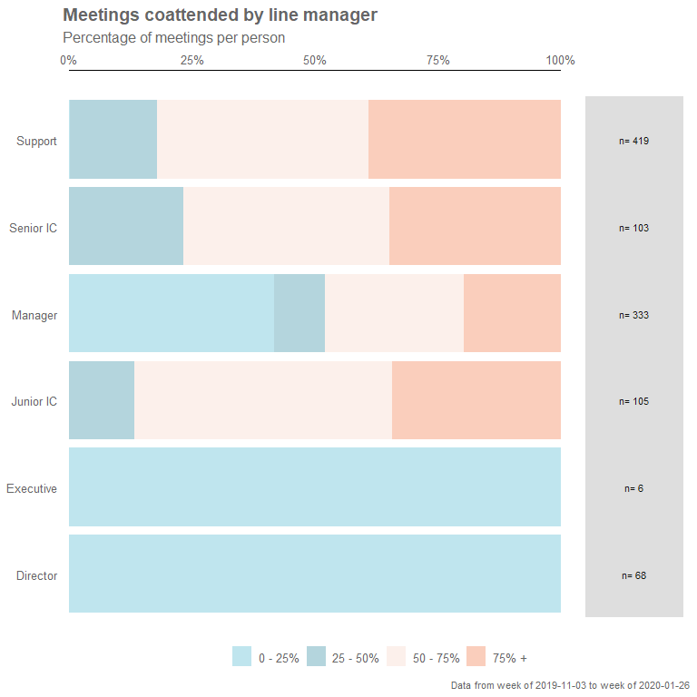

```r
sq_data %>% mgrcoatt_dist(hrvar = "LevelDesignation")
```

A table can be generated:

```r
sq_data %>% mgrcoatt_dist(hrvar = "LevelDesignation", return = "table")
```

```
#> # A tibble: 6 x 5
#>   group     `0 - 25%` `25 - 50%` `50 - 75%` `75% +`
#>   <chr>         <dbl>      <dbl>      <dbl>   <dbl>
#> 1 Director    1           NA         NA      NA
#> 2 Executive   1           NA         NA      NA
#> 3 Junior IC  NA            0.133      0.524   0.343
#> 4 Manager     0.417        0.102      0.282   0.198
#> 5 Senior IC  NA            0.233      0.417   0.350
#> 6 Support     0.00239      0.177      0.430   0.391
```

### Customizing plot outputs

With a few rare exceptions such as `track_HR_change()`, the majority of plot outputs returned by **wpa** functions are ggplot outputs. What this means is that there is a lot of flexibility in adding or overriding visual elements in the plots. For instance, you can take the following ‘fizzy drink’ (jittered scatter) plot:

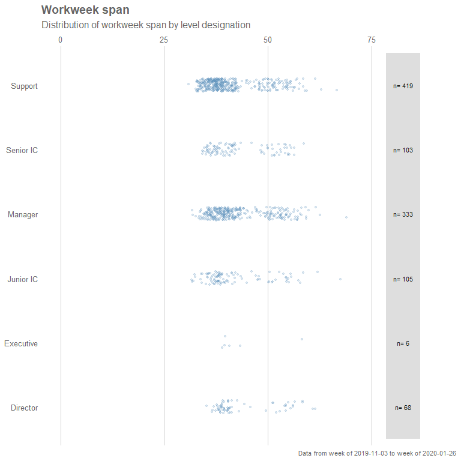

```r
sq_data %>%
  workloads_fizz(hrvar = "LevelDesignation", return = "plot")
```

[figure not shown]

```r
library(ggplot2) # Requires ggplot2 for customizations

sq_data %>%
  workloads_fizz(hrvar = "LevelDesignation", return = "plot") +
  labs(title = "This is a custom title",
       subtitle = "This is a custom sub-title") +
  coord_flip() # Flip coordinates
```

Note that the “pipe” syntax changes from `%>%` to `+` once you are manipulating a ggplot output, which will return an error if not used correctly.

Adding customized elements may ‘break’ the visualization, so please exercise caution when doing so.

For more information on ggplot, please visit https://ggplot2.tidyverse.org/.

### Getting a quick overview of Standard Person Query data

The `collaboration_report()` function enables you to get a quick view of the Standard Query data by producing an automated HTML report. This can be done by passing the dataset as the argument:

```r
sq_data %>% collaboration_report()
```

Running the function will open up a HTML report in your browser, summarising the key collaboration metrics and plots of the Standard Person Query. You can manually save this report, or only have it open as an ad-hoc reference document.

## Feedback

Hope you found this useful! If you have any suggestions or feedback, please log them at https://github.com/microsoft/wpa/issues/.